# Question

A cart is pulled along a level track by a string that runs over a pulley to a hanger. Some mass (cargo) rides on the cart, and some mass (heft) sits on the hanger. Ignore friction and the mass of the string.

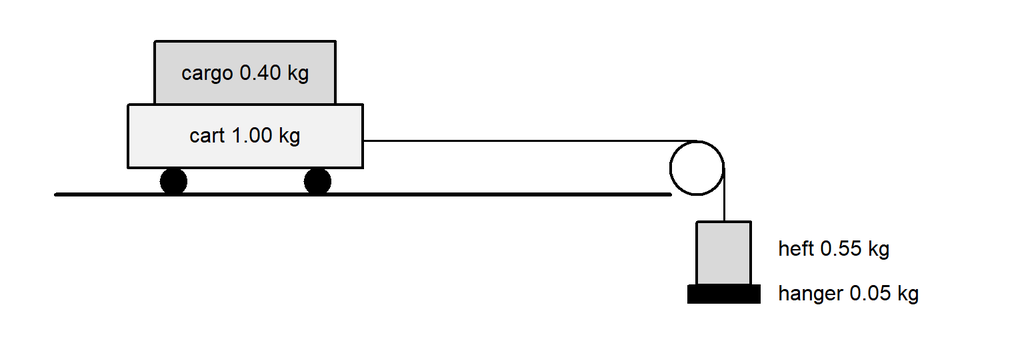

- The **forward force** is the weight of the hanger plus the heft.
- Weight is found by multiplying mass by 10 N/kg.
- The **total mass** being pushed forward is made of all four masses: cart, cargo, hanger, and heft.

## Answerlist

- What is the forward force (in N)?
- What is the total mass (in kg)?
- What is the acceleration of the cart (in m/s$^2$)?

# Solution

The forward force is the weight of the hanger plus the heft. Their total mass is $0.05 + 0.55 = 0.60$ kg, so the weight is $0.60 \times 10 = 6$ N.

The total mass includes all four masses: $1.00 + 0.40 + 0.05 + 0.55 = 2.00$ kg.

The acceleration is the force divided by the total mass: $6 \div 2 = 3$ m/s$^2$.

- $(0.05 + 0.55) \times 10 = 6$ N
- $1.00 + 0.40 + 0.05 + 0.55 = 2.00$ kg
- $6 \div 2 = 3$ m/s$^2$

# Meta-information

exname: Cart, cargo, hanger, heft: force, mass, acceleration extype: cloze exclozetype: num|num|num exsolution: 6|2|3 extol: 0.01